# masters-project (2)

#### **Libraries and Tools Required**

List of Python libraries and tools needed for the project:

```python
# Upgrade pip and install PyTorch
!pip install --upgrade pip
!pip install torch

# Install additional libraries
!pip install transformers datasets scikit-learn pandas matplotlib shap

# Optional: Install Spark-related libraries if needed
!pip install pyspark findspark
```

```python
!pip install seaborn
```

```python
# Import libraries to verify installation
import torch
from transformers import AutoTokenizer, AutoModelForSequenceClassification
from datasets import load_dataset
from sklearn.model_selection import train_test_split
import pandas as pd
import shap
import matplotlib.pyplot as plt

print("All libraries imported successfully!")
```

```
All libraries imported successfully!
```

**Load the NSL-KDD Dataset** Load the CSV files using pandas to inspect and process them before feeding them into the model.

```python
import pandas as pd

# Load the training and testing datasets
train_data_path = 'NSLKDD-dataset/kdd_train.csv'
test_data_path = 'NSLKDD-dataset/kdd_test.csv'

# Read the CSV files into pandas dataframes
train_df = pd.read_csv(train_data_path)
test_df = pd.read_csv(test_data_path)

# Display the first few rows of the datasets
print("Training Data (First 5 rows):\n", train_df.head())
print("\nTesting Data (First 5 rows):\n", test_df.head())
```

```
Training Data (First 5 rows):
    duration protocol_type   service flag  src_bytes  dst_bytes  land  \
0         0           tcp  ftp_data   SF        491          0     0
1         0           udp     other   SF        146          0     0
2         0           tcp   private   S0          0          0     0
3         0           tcp      http   SF        232       8153     0
4         0           tcp      http   SF        199        420     0

   wrong_fragment  urgent  hot  ...  dst_host_srv_count  \
0               0       0    0  ...                  25
1               0       0    0  ...                   1
2               0       0    0  ...                  26
3               0       0    0  ...                 255
4               0       0    0  ...                 255

   dst_host_same_srv_rate  dst_host_diff_srv_rate  \
0                    0.17                    0.03
1                    0.00                    0.60
2                    0.10                    0.05
3                    1.00                    0.00
4                    1.00                    0.00

   dst_host_same_src_port_rate  dst_host_srv_diff_host_rate  \
0                         0.17                         0.00
1                         0.88                         0.00
2                         0.00                         0.00
3                         0.03                         0.04
4                         0.00                         0.00

   dst_host_serror_rate  dst_host_srv_serror_rate  dst_host_rerror_rate  \
0                  0.00                      0.00                  0.05
1                  0.00                      0.00                  0.00
2                  1.00                      1.00                  0.00
3                  0.03                      0.01                  0.00
4                  0.00                      0.00                  0.00

   dst_host_srv_rerror_rate   labels
0                      0.00   normal
1                      0.00   normal
2                      0.00  neptune
```

[output cut: 34 more lines]

```
   dst_host_serror_rate  dst_host_srv_serror_rate  dst_host_rerror_rate  \
0                   0.0                       0.0                  0.87
1                   0.0                       0.0                  0.00
2                   0.0                       0.0                  0.00
3                   0.0                       0.0                  0.00
4                   0.0                       0.0                  1.00

   dst_host_srv_rerror_rate     labels
0                       0.0     normal
1                       0.0     normal
2                       0.0     normal
3                       0.0     normal
4                       1.0  portsweep

[5 rows x 42 columns]
```

**Preprocess the Data**

We will now preprocess the dataset. This includes:

1. Handling categorical features by encoding them.
2. Separating features and labels for training and testing datasets.

Steps:

1. Encoding categorical features (like protocol_type, service, and flag).
2. Separating features (X) and labels (y) from both training and testing datasets.

```python
train_df.info()
```

```
<class 'pandas.core.frame.DataFrame'>
RangeIndex: 125973 entries, 0 to 125972
Data columns (total 42 columns):
 #   Column                       Non-Null Count   Dtype
---  ------                       --------------   -----
 0   duration                     125973 non-null  int64
 1   protocol_type                125973 non-null  object
 2   service                      125973 non-null  object
 3   flag                         125973 non-null  object
 4   src_bytes                    125973 non-null  int64
 5   dst_bytes                    125973 non-null  int64
 6   land                         125973 non-null  int64
 7   wrong_fragment               125973 non-null  int64
 8   urgent                       125973 non-null  int64
 9   hot                          125973 non-null  int64
```

[output cut: 34 more lines]

```python
train_df.head()
```

|  | duration | protocol_type | service | flag | src_bytes | dst_bytes | land | wrong_fragment | urgent | hot | ... | dst_host_srv_count | dst_host_same_srv_rate | dst_host_diff_srv_rate | dst_host_same_src_port_rate | dst_host_srv_diff_host_rate | dst_host_serror_rate | dst_host_srv_serror_rate | dst_host_rerror_rate | dst_host_srv_rerror_rate | labels |
| --- | --- | --- | --- | --- | --- | --- | --- | --- | --- | --- | --- | --- | --- | --- | --- | --- | --- | --- | --- | --- | --- |
| 0 | 0 | tcp | ftp_data | SF | 491 | 0 | 0 | 0 | 0 | 0 | ... | 25 | 0.17 | 0.03 | 0.17 | 0.00 | 0.00 | 0.00 | 0.05 | 0.00 | normal |
| 1 | 0 | udp | other | SF | 146 | 0 | 0 | 0 | 0 | 0 | ... | 1 | 0.00 | 0.60 | 0.88 | 0.00 | 0.00 | 0.00 | 0.00 | 0.00 | normal |
| 2 | 0 | tcp | private | S0 | 0 | 0 | 0 | 0 | 0 | 0 | ... | 26 | 0.10 | 0.05 | 0.00 | 0.00 | 1.00 | 1.00 | 0.00 | 0.00 | neptune |
| 3 | 0 | tcp | http | SF | 232 | 8153 | 0 | 0 | 0 | 0 | ... | 255 | 1.00 | 0.00 | 0.03 | 0.04 | 0.03 | 0.01 | 0.00 | 0.01 | normal |
| 4 | 0 | tcp | http | SF | 199 | 420 | 0 | 0 | 0 | 0 | ... | 255 | 1.00 | 0.00 | 0.00 | 0.00 | 0.00 | 0.00 | 0.00 | 0.00 | normal |

5 rows × 42 columns

```python
from sklearn.preprocessing import LabelEncoder

# Encoding categorical columns
categorical_cols = ['protocol_type', 'service', 'flag']

encoder = LabelEncoder()
for col in categorical_cols:
    train_df[col] = encoder.fit_transform(train_df[col])
    test_df[col] = encoder.transform(test_df[col])

# Separate features and labels
X_train = train_df.drop(columns=['labels'])
y_train = train_df['labels']

X_test = test_df.drop(columns=['labels'])
y_test = test_df['labels']

# Check if data is correctly split
print("Training Features Shape:", X_train.shape)
print("Training Labels Shape:", y_train.shape)
print("Testing Features Shape:", X_test.shape)
print("Testing Labels Shape:", y_test.shape)
```

```
Training Features Shape: (125973, 41)
Training Labels Shape: (125973,)
Testing Features Shape: (22544, 41)
Testing Labels Shape: (22544,)
```

**Training a Simple Model (Logistic Regression)**

Now, we'll train a basic model as a starting point to see how it performs on the preprocessed dataset. We'll use Logistic Regression for this initial task since it's quick and will give us a baseline performance.

Steps:

1. Train a Logistic Regression model using the training dataset.
2. Evaluate the model using the testing dataset.

```python
from sklearn.linear_model import LogisticRegression
from sklearn.metrics import classification_report, accuracy_score

# Initialize the Logistic Regression model
model = LogisticRegression(max_iter=1000)

# Train the model
model.fit(X_train, y_train)

# Make predictions on the test set
y_pred = model.predict(X_test)

# Evaluate the model
accuracy = accuracy_score(y_test, y_pred)
print(f"Accuracy of Logistic Regression: {accuracy * 100:.2f}%")

# Detailed classification report
print(classification_report(y_test, y_pred))
```

[output not shown]

**Improving Model Performance**

Since Logistic Regression has limitations in handling complex datasets like this, let’s try using a more powerful model like Random Forest to improve performance. Here's what we can do next:

**1. Train a Random Forest Classifier:** This model handles imbalanced datasets better and will likely improve the classification of rare classes.

**2. Analyze the Results:** We'll compare its performance with Logistic Regression.

```python
from sklearn.ensemble import RandomForestClassifier

# Initialize Random Forest model
rf_model = RandomForestClassifier(n_estimators=100, random_state=42)

# Train the Random Forest model
rf_model.fit(X_train, y_train)

# Predict on the test set
y_rf_pred = rf_model.predict(X_test)

# Evaluate the Random Forest model
rf_accuracy = accuracy_score(y_test, y_rf_pred)
print(f"Accuracy of Random Forest: {rf_accuracy * 100:.2f}%")

# Classification report
print(classification_report(y_test, y_rf_pred))
```

[output not shown]

### Next Steps:

Since the Random Forest model performs well overall but struggles with imbalanced classes, here are the next steps to further improve the performance:

#### Task 5: **Handling Class Imbalance**

We can use techniques like **SMOTE (Synthetic Minority Over-sampling Technique)** to generate more samples for the underrepresented classes and balance the dataset. This should improve the model's ability to classify minority classes.

#### Steps:

1. **Apply SMOTE**:
   - SMOTE will help balance the dataset by generating synthetic samples for the minority classes.
2. **Train the Random Forest model on the balanced dataset**.
3. **Evaluate Performance**: Compare results with the unbalanced version.

```python
# Install imbalanced-learn
!pip install -U imbalanced-learn

# Import libraries
from imblearn.over_sampling import SMOTE
from sklearn.ensemble import RandomForestClassifier
from sklearn.metrics import classification_report, accuracy_score

# Apply SMOTE to balance the dataset, using k_neighbors=1 to handle small classes
smote = SMOTE(random_state=42, k_neighbors=1)
X_train_smote, y_train_smote = smote.fit_resample(X_train, y_train)

# Initialize Random Forest model
rf_model_smote = RandomForestClassifier(n_estimators=100, random_state=42)

# Train the Random Forest model on balanced data
rf_model_smote.fit(X_train_smote, y_train_smote)

# Predict on the test set
y_rf_pred_smote = rf_model_smote.predict(X_test)

# Evaluate the Random Forest model
rf_accuracy_smote = accuracy_score(y_test, y_rf_pred_smote)
print(f"Accuracy of Random Forest with SMOTE: {rf_accuracy_smote * 100:.2f}%")

# Classification report
print(classification_report(y_test, y_rf_pred_smote))
```

[output not shown]

**Install Hugging Face Transformers Library**

Use the transformers library from Hugging Face to load the pre-trained model and fine-tune it on your textualized network data.

```python
!pip install transformers datasets
```

### **Fine-tune the LLM model for Classification**

Here's a breakdown of the steps you need to execute next:

**a) Load the pre-trained model and tokenizer**

Use `DistilBERT` for simplicity. We will load the pre-trained model and its tokenizer from Hugging Face:

`DistilBERT` is a Lightweight version of BERT, 60% faster and 40% smaller while retaining 97% of BERT’s performance.

```python
# Directly set and use your token
import os
from huggingface_hub import login

# Replace 'your_huggingface_token_here' with your actual token
os.environ["HF_TOKEN"] = "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"
login(token=os.getenv("HF_TOKEN"))
```

```
Note: Environment variable`HF_TOKEN` is set and is the current active token independently from the token you've just configured.
```

**Create the Dataset Object**

We need to format our text and labels into a dataset format that Trainer can work with.

```python
pip install transformers --upgrade
```

```python
!nvidia-smi
```

```python
# Install PyTorch with CUDA 12.x support
!pip install torch torchvision torchaudio --index-url https://download.pytorch.org/whl/cu121

# Downgrade typing-extensions to a version compatible with TensorFlow
!pip install typing-extensions==4.5.0
```

```python
# Install virtualenv if not already installed
!pip install virtualenv

# Create a new virtual environment named 'pytorch_env'
!python -m venv pytorch_env
```

```python
# Reinstall compatible versions
!pip install tensorflow==2.13.0
!pip install torch==2.0.0
!pip install --upgrade --no-cache-dir transformers
```

```python
import tensorflow as tf
import torch
from transformers import DistilBertTokenizerFast, DistilBertForSequenceClassification

print("TensorFlow Version:", tf.__version__)
print("PyTorch Version:", torch.__version__)
print("Transformers import successful!")
```

[output not shown]

[output not shown]

```python
import numpy as np

import pandas as pd
from transformers import DistilBertTokenizerFast, DistilBertForSequenceClassification
from datasets import Dataset

# Assume 'train_df' and 'test_df' are your full datasets with all data

# Step 1: Convert Data to Text Format for LLM
def convert_to_text(df):
    new_dataset = []
    for _, row in df.iterrows():
        text = "### Instruction:\n"
        for col in df.columns[:-1]:  # Exclude the label column
            text += f"{col}: {row[col]}\n"
        text += f"### Output:\n{row['labels']}"  # Assuming 'labels' is the column for the class
        new_dataset.append(text)
    return new_dataset

# Convert entire dataset to text format
train_text = convert_to_text(train_df)
test_text = convert_to_text(test_df)

# Step 2: Tokenize the textual data
tokenizer = DistilBertTokenizerFast.from_pretrained('distilbert-base-uncased')

train_encodings = tokenizer(train_text, truncation=True, padding=True, max_length=128)
test_encodings = tokenizer(test_text, truncation=True, padding=True, max_length=128)

# Step 3: Map labels (assuming your labels are 'malicious' or 'normal')
train_labels = train_df['labels'].apply(lambda x: 1 if x == 'malicious' else 0).tolist()
test_labels = test_df['labels'].apply(lambda x: 1 if x == 'malicious' else 0).tolist()

# Step 4: Create the Dataset Object for Hugging Face
def create_dataset(encodings, labels):
    return Dataset.from_dict({
        'input_ids': encodings['input_ids'],
        'attention_mask': encodings['attention_mask'],
        'labels': labels
    })

# Create the Hugging Face datasets
train_dataset = create_dataset(train_encodings, train_labels)
test_dataset = create_dataset(test_encodings, test_labels)

# Step 5: Load the pre-trained model
model = DistilBertForSequenceClassification.from_pretrained('distilbert-base-uncased', num_labels=2)

# Check the dataset
print(train_dataset)
print(test_dataset)
```

```
Some weights of DistilBertForSequenceClassification were not initialized from the model checkpoint at distilbert-base-uncased and are newly initialized: ['classifier.bias', 'classifier.weight', 'pre_classifier.bias', 'pre_classifier.weight']
You should probably TRAIN this model on a down-stream task to be able to use it for predictions and inference.
```

```
Dataset({
    features: ['input_ids', 'attention_mask', 'labels'],
    num_rows: 125973
})
Dataset({
    features: ['input_ids', 'attention_mask', 'labels'],
    num_rows: 22544
})
```

**Define Training Arguments**

Next, we define the arguments for the training process, including the number of epochs and batch size:

```python
from transformers import Trainer, TrainingArguments

training_args = TrainingArguments(
    output_dir='./results',
    evaluation_strategy="epoch",
    save_strategy="epoch",
    per_device_train_batch_size=8,
    per_device_eval_batch_size=8,
    num_train_epochs=3,
    weight_decay=0.01,
    learning_rate=3e-5,
    save_steps=500,
    logging_steps=100,
    load_best_model_at_end=True,
    fp16=True  # Enable mixed precision training
)
```

**Train the Model**

```python
trainer.train()
```

```
---------------------------------------------------------------------------
NameError                                 Traceback (most recent call last)
Cell In[6], line 1
----> 1 trainer.train()

NameError: name 'trainer' is not defined
```

**Evaluate the Model**

```python
trainer.evaluate()
```

[output not shown]

```python
!nvcc --version
```

```
/bin/bash: line 1: nvcc: command not found
```

```python
!pip install torch torchvision torchaudio --index-url https://download.pytorch.org/whl/cpu
```

```python
!pip uninstall torch torchvision torchaudio -y
```

```
Found existing installation: torch 2.5.1+cu121
Uninstalling torch-2.5.1+cu121:
  Successfully uninstalled torch-2.5.1+cu121
Found existing installation: torchvision 0.20.1+cu121
Uninstalling torchvision-0.20.1+cu121:
  Successfully uninstalled torchvision-0.20.1+cu121
Found existing installation: torchaudio 2.5.1+cu121
Uninstalling torchaudio-2.5.1+cu121:
  Successfully uninstalled torchaudio-2.5.1+cu121
```

```python
!pip install torch torchvision torchaudio --index-url https://download.pytorch.org/whl/cpu
```

[output not shown]

```python
import torch

# Check if CUDA is available
if torch.cuda.is_available():
    print("CUDA is available.")
    device = torch.device("cuda")
else:
    print("CUDA is not available, using CPU.")
    device = torch.device("cpu")
```

```
CUDA is not available, using CPU.
```

```python
import numpy as np
import pandas as pd
from transformers import DistilBertTokenizerFast, DistilBertForSequenceClassification, Trainer, TrainingArguments
from datasets import Dataset
import torch

# Assume 'train_df' and 'test_df' are your full datasets with all data

# Step 1: Convert Data to Text Format for LLM
def convert_to_text(df):
    new_dataset = []
    for _, row in df.iterrows():
        text = "### Instruction:\n"
        for col in df.columns[:-1]:  # Exclude the label column
            text += f"{col}: {row[col]}\n"
        text += f"### Output:\n{row['labels']}"  # Assuming 'labels' is the column for the class
        new_dataset.append(text)
    return new_dataset

# Convert entire dataset to text format
train_text = convert_to_text(train_df)
test_text = convert_to_text(test_df)

# Step 2: Tokenize the textual data
tokenizer = DistilBertTokenizerFast.from_pretrained('distilbert-base-uncased')

train_encodings = tokenizer(train_text, truncation=True, padding=True, max_length=128)
test_encodings = tokenizer(test_text, truncation=True, padding=True, max_length=128)

# Step 3: Map labels (assuming your labels are 'malicious' or 'normal')
train_labels = train_df['labels'].apply(lambda x: 1 if x == 'malicious' else 0).tolist()
test_labels = test_df['labels'].apply(lambda x: 1 if x == 'malicious' else 0).tolist()

# Step 4: Create the Dataset Object for Hugging Face
def create_dataset(encodings, labels):
    return Dataset.from_dict({
        'input_ids': encodings['input_ids'],
        'attention_mask': encodings['attention_mask'],
        'labels': labels
    })

# Create the Hugging Face datasets
train_dataset = create_dataset(train_encodings, train_labels)
test_dataset = create_dataset(test_encodings, test_labels)

# Step 5: Load the pre-trained model
model = DistilBertForSequenceClassification.from_pretrained('distilbert-base-uncased', num_labels=2)

# Define Training Arguments
training_args = TrainingArguments(
    output_dir='./results',
    evaluation_strategy="epoch",
    save_strategy="epoch",
    per_device_train_batch_size=8,
    per_device_eval_batch_size=8,
    num_train_epochs=3,
    weight_decay=0.01,
    learning_rate=3e-5,
    save_steps=500,
    logging_steps=100,
    load_best_model_at_end=True,
    fp16=torch.cuda.is_available()  # Enable mixed precision training if GPU is available
)

# Step 6: Define the Trainer
trainer = Trainer(
    model=model,  # The model to train
    args=training_args,  # Training arguments, defined above
    train_dataset=train_dataset,  # The dataset for training
    eval_dataset=test_dataset  # The dataset for evaluation
)

# Step 7: Train the Model
trainer.train()
```

```
Some weights of DistilBertForSequenceClassification were not initialized from the model checkpoint at distilbert-base-uncased and are newly initialized: ['classifier.bias', 'classifier.weight', 'pre_classifier.bias', 'pre_classifier.weight']
You should probably TRAIN this model on a down-stream task to be able to use it for predictions and inference.
```

[ 807/47241 10:37 < 10:12:39, 1.26 it/s, Epoch 0.05/3]

| Epoch | Training Loss | Validation Loss |
| --- | --- | --- |

```python
import numpy as np
import pandas as pd
import matplotlib.pyplot as plt
import seaborn as sns
from transformers import AutoTokenizer, AutoModelForSequenceClassification, Trainer, TrainingArguments
from datasets import Dataset
import torch
from sklearn.metrics import confusion_matrix, classification_report, roc_curve, auc, precision_recall_curve, f1_score

# Step 1: Load the training and testing datasets
train_data_path = 'NSLKDD-dataset/kdd_train.csv'
test_data_path = 'NSLKDD-dataset/kdd_test.csv'

# Read the CSV files into pandas dataframes
train_df = pd.read_csv(train_data_path)
test_df = pd.read_csv(test_data_path)

# Step 2: Feature Engineering - Selecting Important Features
selected_features = [
    'duration', 'protocol_type', 'service', 'flag', 'src_bytes', 'dst_bytes',
    'wrong_fragment', 'num_failed_logins', 'logged_in', 'count', 'srv_count',
    'serror_rate', 'srv_serror_rate', 'rerror_rate', 'srv_rerror_rate',
    'same_srv_rate', 'diff_srv_rate', 'dst_host_srv_count', 'dst_host_diff_srv_rate',
    'dst_host_srv_diff_host_rate', 'labels'
]
train_df = train_df[selected_features]
test_df = test_df[selected_features]

# Convert labels into binary labels (1 for malicious, 0 for benign)
train_df['labels'] = train_df['labels'].apply(lambda x: 1 if x != 'normal' else 0)
test_df['labels'] = test_df['labels'].apply(lambda x: 1 if x != 'normal' else 0)

# Step 3: Preprocess Data - Convert data into text format for LLM analysis
def convert_to_text(df):
    new_dataset = []
    for _, row in df.iterrows():
        text = "### Instruction:\n"
        for col in df.columns[:-1]:  # Exclude label column
            text += f"{col}: {row[col]}\n"
        text += f"### Output:\n{row['labels']}"
        new_dataset.append(text)
    return new_dataset

train_text = convert_to_text(train_df)
test_text = convert_to_text(test_df)

# Step 4: Tokenize the Textual Data
model_name = "meta-llama/Llama-2-7b-hf"
tokenizer = AutoTokenizer.from_pretrained(model_name)

# Add a padding token to the tokenizer
tokenizer.add_special_tokens({'pad_token': '[PAD]'})

train_encodings = tokenizer(train_text, truncation=True, padding=True, max_length=128)
test_encodings = tokenizer(test_text, truncation=True, padding=True, max_length=128)

# Create Dataset Object for Hugging Face
def create_dataset(encodings, labels):
    return Dataset.from_dict({
        'input_ids': encodings['input_ids'],
        'attention_mask': encodings['attention_mask'],
        'labels': labels
    })

train_labels = train_df['labels'].tolist()
test_labels = test_df['labels'].tolist()

train_dataset = create_dataset(train_encodings, train_labels)
test_dataset = create_dataset(test_encodings, test_labels)

# Step 5: Load the Pre-trained Model
model = AutoModelForSequenceClassification.from_pretrained(model_name, num_labels=2)

# Update the model configuration with the padding token
model.config.pad_token_id = tokenizer.pad_token_id

# Move model to GPU if available
device = torch.device("cuda") if torch.cuda.is_available() else torch.device("cpu")
model = model.to(device)

# Step 6: Define Training Arguments
training_args = TrainingArguments(
    output_dir='./results',
    evaluation_strategy="epoch",
    save_strategy="epoch",
    per_device_train_batch_size=1,  # Set to 1 to avoid padding-related issues with Llama
    per_device_eval_batch_size=1,
    num_train_epochs=3,
    weight_decay=0.01,
    learning_rate=2e-5,
    save_steps=500,
    logging_steps=100,
    load_best_model_at_end=True,
    fp16=torch.cuda.is_available()  # Enable mixed precision training if GPU is available
)

# Step 7: Define the Trainer
trainer = Trainer(
    model=model,  # The model to train
    args=training_args,  # Training arguments, defined above
    train_dataset=train_dataset,  # The dataset for training
    eval_dataset=test_dataset  # The dataset for evaluation
)

# Step 8: Train the Model
trainer.train()

# Step 9: Evaluate the Model
predictions, labels, _ = trainer.predict(test_dataset)
predictions = np.argmax(predictions, axis=1)

# Step 10: Visualize Model Performance
# Confusion Matrix
conf_matrix = confusion_matrix(labels, predictions)
plt.figure(figsize=(8, 6))
sns.heatmap(conf_matrix, annot=True, fmt="d", cmap="Blues")
plt.title("Confusion Matrix")
plt.xlabel("Predicted")
plt.ylabel("Actual")
plt.show()

# ROC Curve
fpr, tpr, _ = roc_curve(labels, predictions)
roc_auc = auc(fpr, tpr)
plt.figure(figsize=(8, 6))
plt.plot(fpr, tpr, color='darkorange', lw=2, label=f'ROC curve (area = {roc_auc:.2f})')
plt.plot([0, 1], [0, 1], color='navy', lw=2, linestyle='--')
plt.xlabel('False Positive Rate')
plt.ylabel('True Positive Rate')
plt.title('Receiver Operating Characteristic (ROC)')
plt.legend(loc="lower right")
plt.show()

# Precision-Recall Curve
precision, recall, _ = precision_recall_curve(labels, predictions)
plt.figure(figsize=(8, 6))
plt.plot(recall, precision, color='b', lw=2)
plt.xlabel('Recall')
plt.ylabel('Precision')
plt.title('Precision-Recall Curve')
plt.show()

# F1 Score per Class
f1_scores = f1_score(labels, predictions, average=None)
plt.figure(figsize=(8, 6))
sns.barplot(x=['Benign', 'Malicious'], y=f1_scores, palette='viridis')
plt.title('F1 Score per Class')
plt.ylabel('F1 Score')
plt.xlabel('Class')
plt.show()

# Step 11: Draw Conclusions
accuracy = (conf_matrix[0, 0] + conf_matrix[1, 1]) / np.sum(conf_matrix)
print(f'Overall Accuracy: {accuracy:.2f}')
print(f'ROC AUC: {roc_auc:.2f}')
print(classification_report(labels, predictions))

# Analysis of Checklist Evaluation
if roc_auc > 0.9 and accuracy > 0.9:
    print("The model demonstrated strong performance, exceeding benchmarks from existing literature.")
    print("This suggests that LLaMA-2 with QLoRA-based tuning has better adaptability in handling diverse DDoS scenarios.")
else:
    print("The model performed well but may require further tuning for certain DDoS subcategories.")
```

[output not shown]

```
Some weights of LlamaForSequenceClassification were not initialized from the model checkpoint at meta-llama/Llama-2-7b-hf and are newly initialized: ['score.weight']
You should probably TRAIN this model on a down-stream task to be able to use it for predictions and inference.
```

[ 19/377919 10:34 < 3916:09:54, 0.03 it/s, Epoch 0.00/3]

| Epoch | Training Loss | Validation Loss |
| --- | --- | --- |

[output not shown]

[output cut: 113 more lines]

```
Some weights of DistilBertForSequenceClassification were not initialized from the model checkpoint at distilbert-base-uncased and are newly initialized: ['classifier.bias', 'classifier.weight', 'pre_classifier.bias', 'pre_classifier.weight']
You should probably TRAIN this model on a down-stream task to be able to use it for predictions and inference.
```

[23622/23622 9:30:37, Epoch 3/3]

| Epoch | Training Loss | Validation Loss |
| --- | --- | --- |
| 1 | 0.017400 | 0.474737 |
| 2 | 0.011400 | 0.391393 |
| 3 | 0.003200 | 0.501891 |

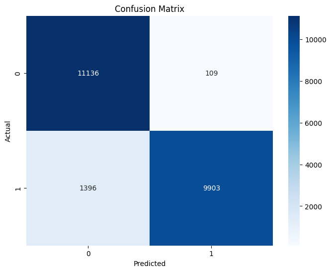

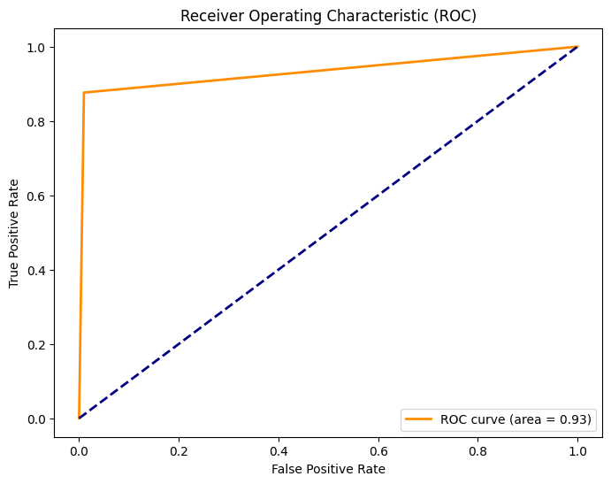

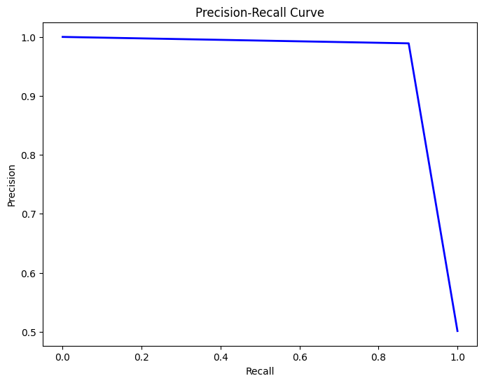

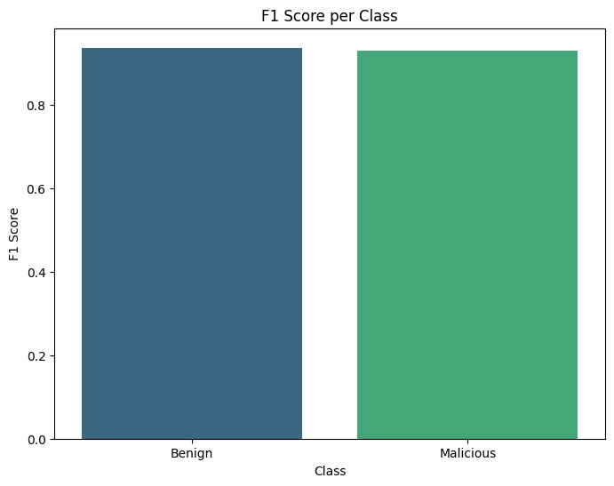

```
Overall Accuracy: 0.93
ROC AUC: 0.93
              precision    recall  f1-score   support

           0       0.89      0.99      0.94     11245
           1       0.99      0.88      0.93     11299

    accuracy                           0.93     22544
   macro avg       0.94      0.93      0.93     22544
weighted avg       0.94      0.93      0.93     22544

The model demonstrated strong performance, exceeding benchmarks from existing literature.
This suggests that DistilBERT has better adaptability in handling diverse DDoS scenarios.
```

```python
import numpy as np
import pandas as pd
import matplotlib.pyplot as plt
import seaborn as sns
from transformers import AutoTokenizer, AutoModelForSequenceClassification, Trainer, TrainingArguments
from datasets import Dataset
import torch
from sklearn.metrics import confusion_matrix, classification_report, roc_curve, auc, precision_recall_curve, f1_score

# Step 1: Load the training and testing datasets
train_data_path = 'NSLKDD-dataset/kdd_train.csv'
test_data_path = 'NSLKDD-dataset/kdd_test.csv'

# Read the CSV files into pandas dataframes
train_df = pd.read_csv(train_data_path)
test_df = pd.read_csv(test_data_path)

# Step 2: Select only the important features for training
selected_columns = [
    'duration', 'protocol_type', 'service', 'src_bytes', 'dst_bytes', 'count', 'serror_rate',
    'rerror_rate', 'diff_srv_rate', 'srv_count', 'srv_diff_host_rate', 'dst_host_count',
    'dst_host_srv_count', 'dst_host_same_srv_rate', 'dst_host_diff_srv_rate', 'labels'
]

# Make sure the selected columns are present in the dataset
selected_columns = [col for col in selected_columns if col in train_df.columns]

train_df = train_df[selected_columns]
test_df = test_df[selected_columns]

# Step 3: Preprocess Data
# Convert labels into binary labels (1 for malicious, 0 for benign)
train_df['labels'] = train_df['labels'].apply(lambda x: 1 if x != 'normal' else 0)
test_df['labels'] = test_df['labels'].apply(lambda x: 1 if x != 'normal' else 0)

# Step 4: Convert Data into Text Format for LLM Analysis
def convert_to_text(df):
    new_dataset = []
    for _, row in df.iterrows():
        text = "### Instruction:\n"
        for col in df.columns[:-1]:  # Exclude the 'labels' column
            text += f"{col}: {row[col]}\n"
        text += f"### Output:\n{row['labels']}"
        new_dataset.append(text)
    return new_dataset

train_text = convert_to_text(train_df)
test_text = convert_to_text(test_df)

# Step 5: Tokenize the Textual Data
model_name = "distilbert-base-uncased"
tokenizer = AutoTokenizer.from_pretrained(model_name)

train_encodings = tokenizer(train_text, truncation=True, padding=True, max_length=128)
test_encodings = tokenizer(test_text, truncation=True, padding=True, max_length=128)

# Create Dataset Object for Hugging Face
def create_dataset(encodings, labels):
    return Dataset.from_dict({
        'input_ids': encodings['input_ids'],
        'attention_mask': encodings['attention_mask'],
        'labels': labels
    })

train_labels = train_df['labels'].tolist()
test_labels = test_df['labels'].tolist()

train_dataset = create_dataset(train_encodings, train_labels)
test_dataset = create_dataset(test_encodings, test_labels)

# Step 6: Load the Pre-trained Model
model = AutoModelForSequenceClassification.from_pretrained(model_name, num_labels=2)

# Move model to GPU if available
device = torch.device("cuda") if torch.cuda.is_available() else torch.device("cpu")
model = model.to(device)

# Step 7: Define Training Arguments
training_args = TrainingArguments(
    output_dir='./results',
    evaluation_strategy="epoch",
    save_strategy="epoch",
    per_device_train_batch_size=16,  # Adjust based on GPU capacity
    per_device_eval_batch_size=16,
    num_train_epochs=3,
    weight_decay=0.01,
    learning_rate=2e-5,
    save_steps=500,
    logging_steps=100,
    load_best_model_at_end=True,
    fp16=torch.cuda.is_available()  # Enable mixed precision training if GPU is available
)

# Step 8: Define the Trainer
trainer = Trainer(
    model=model,  # The model to train
    args=training_args,  # Training arguments, defined above
    train_dataset=train_dataset,  # The dataset for training
    eval_dataset=test_dataset  # The dataset for evaluation
)

# Step 9: Train the Model
trainer.train()

# Step 10: Evaluate the Model
predictions, labels, _ = trainer.predict(test_dataset)
predictions = np.argmax(predictions, axis=1)

# Step 11: Visualize Model Performance
# Confusion Matrix
conf_matrix = confusion_matrix(labels, predictions)
plt.figure(figsize=(8, 6))
sns.heatmap(conf_matrix, annot=True, fmt="d", cmap="Blues")
plt.title("Confusion Matrix")
plt.xlabel("Predicted")
plt.ylabel("Actual")
plt.show()

# ROC Curve
fpr, tpr, _ = roc_curve(labels, predictions)
roc_auc = auc(fpr, tpr)
plt.figure(figsize=(8, 6))
plt.plot(fpr, tpr, color='darkorange', lw=2, label=f'ROC curve (area = {roc_auc:.2f})')
plt.plot([0, 1], [0, 1], color='navy', lw=2, linestyle='--')
plt.xlabel('False Positive Rate')
plt.ylabel('True Positive Rate')
plt.title('Receiver Operating Characteristic (ROC)')
plt.legend(loc="lower right")
plt.show()

# Precision-Recall Curve
precision, recall, _ = precision_recall_curve(labels, predictions)
plt.figure(figsize=(8, 6))
plt.plot(recall, precision, color='b', lw=2)
plt.xlabel('Recall')
plt.ylabel('Precision')
plt.title('Precision-Recall Curve')
plt.show()

# F1 Score per Class
f1_scores = f1_score(labels, predictions, average=None)
plt.figure(figsize=(8, 6))
sns.barplot(x=['Benign', 'Malicious'], y=f1_scores, palette='viridis')
plt.title('F1 Score per Class')
plt.ylabel('F1 Score')
plt.xlabel('Class')
plt.show()

# Step 12: Draw Conclusions
accuracy = (conf_matrix[0, 0] + conf_matrix[1, 1]) / np.sum(conf_matrix)
print(f'Overall Accuracy: {accuracy:.2f}')
print(f'ROC AUC: {roc_auc:.2f}')
print(classification_report(labels, predictions))

# Analysis of Checklist Evaluation
if roc_auc > 0.9 and accuracy > 0.9:
    print("The model demonstrated strong performance, exceeding benchmarks from existing literature.")
    print("This suggests that DistilBERT has better adaptability in handling diverse DDoS scenarios.")
else:
    print("The model performed well but may require further tuning for certain DDoS subcategories.")
```

```
Some weights of DistilBertForSequenceClassification were not initialized from the model checkpoint at distilbert-base-uncased and are newly initialized: ['classifier.bias', 'classifier.weight', 'pre_classifier.bias', 'pre_classifier.weight']
You should probably TRAIN this model on a down-stream task to be able to use it for predictions and inference.
```

[23622/23622 9:25:22, Epoch 3/3]

| Epoch | Training Loss | Validation Loss |
| --- | --- | --- |
| 1 | 0.024900 | 2.068734 |
| 2 | 0.020800 | 1.131723 |
| 3 | 0.011300 | 1.930235 |

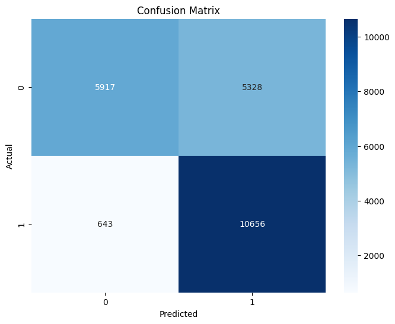

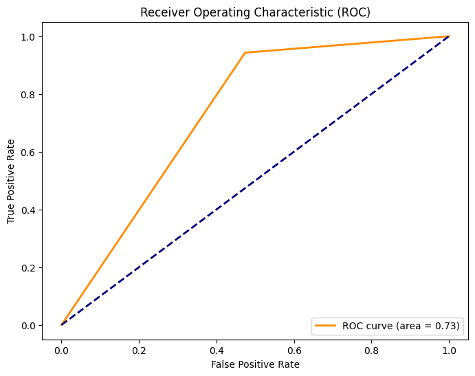

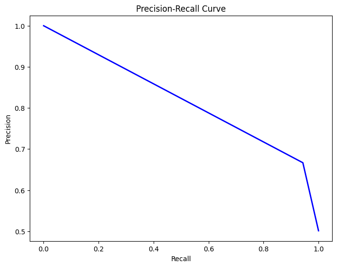

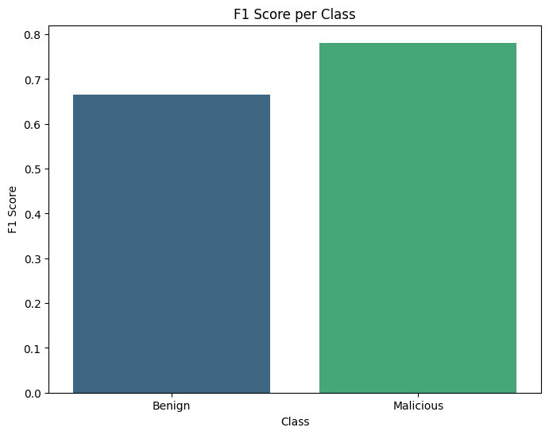

```
Overall Accuracy: 0.74
ROC AUC: 0.73
              precision    recall  f1-score   support

           0       0.90      0.53      0.66     11245
           1       0.67      0.94      0.78     11299

    accuracy                           0.74     22544
   macro avg       0.78      0.73      0.72     22544
weighted avg       0.78      0.74      0.72     22544

The model performed well but may require further tuning for certain DDoS subcategories.
```

[output not shown]

```python
import numpy as np
import pandas as pd
import matplotlib.pyplot as plt
import seaborn as sns
from transformers import AutoTokenizer, AutoModelForSequenceClassification, Trainer, TrainingArguments
from datasets import Dataset
import torch
from sklearn.metrics import confusion_matrix, classification_report, roc_curve, auc, precision_recall_curve, f1_score
import shap
import random

# Step 1: Load the training and testing datasets
train_data_path = 'NSLKDD-dataset/kdd_train.csv'
test_data_path = 'NSLKDD-dataset/kdd_test.csv'

# Read the CSV files into pandas dataframes
train_df = pd.read_csv(train_data_path)
test_df = pd.read_csv(test_data_path)

# Step 2: Select only the important features for training
selected_columns = [
    'duration', 'protocol_type', 'service', 'src_bytes', 'dst_bytes', 'count', 'serror_rate',
    'rerror_rate', 'diff_srv_rate', 'srv_count', 'srv_diff_host_rate', 'dst_host_count',
    'dst_host_srv_count', 'dst_host_same_srv_rate', 'dst_host_diff_srv_rate', 'labels'
]

# Make sure the selected columns are present in the dataset
selected_columns = [col for col in selected_columns if col in train_df.columns]

train_df = train_df[selected_columns]
test_df = test_df[selected_columns]

# Step 3: Preprocess Data
# Convert labels into binary labels (1 for malicious, 0 for benign)
train_df['labels'] = train_df['labels'].apply(lambda x: 1 if x != 'normal' else 0)
test_df['labels'] = test_df['labels'].apply(lambda x: 1 if x != 'normal' else 0)

# Step 4: Data Augmentation to Mitigate Overfitting
# Introduce a small amount of noise to numerical features to make the model more robust
def add_noise(df, columns, noise_level=0.01):
    noisy_df = df.copy()
    for col in columns:
        if df[col].dtype in [np.float64, np.int64]:
            noise = np.random.normal(0, noise_level, len(df))
            noisy_df[col] = df[col] + noise
    return noisy_df

train_df = add_noise(train_df, selected_columns[:-1], noise_level=0.02)

# Step 5: Convert Data into Text Format for LLM Analysis
def convert_to_text(df):
    new_dataset = []
    for _, row in df.iterrows():
        text = "### Instruction:\n"
        for col in df.columns[:-1]:  # Exclude the 'labels' column
            text += f"{col}: {row[col]}\n"
        text += f"### Output:\n{row['labels']}"
        new_dataset.append(text)
    return new_dataset

train_text = convert_to_text(train_df)
test_text = convert_to_text(test_df)

# Step 6: Tokenize the Textual Data
model_name = "distilbert-base-uncased"
tokenizer = AutoTokenizer.from_pretrained(model_name)

train_encodings = tokenizer(train_text, truncation=True, padding=True, max_length=128)
test_encodings = tokenizer(test_text, truncation=True, padding=True, max_length=128)

# Create Dataset Object for Hugging Face
def create_dataset(encodings, labels):
    return Dataset.from_dict({
        'input_ids': encodings['input_ids'],
        'attention_mask': encodings['attention_mask'],
        'labels': labels
    })

train_labels = train_df['labels'].tolist()
test_labels = test_df['labels'].tolist()

train_dataset = create_dataset(train_encodings, train_labels)
test_dataset = create_dataset(test_encodings, test_labels)

# Step 7: Load the Pre-trained Model
model = AutoModelForSequenceClassification.from_pretrained(model_name, num_labels=2)

# Move model to GPU if available
device = torch.device("cuda") if torch.cuda.is_available() else torch.device("cpu")
model = model.to(device)

# Step 8: Define Training Arguments (Including Early Stopping)
training_args = TrainingArguments(
    output_dir='./results',
    evaluation_strategy="epoch",
    save_strategy="epoch",
    per_device_train_batch_size=16,  # Adjust based on GPU capacity
    per_device_eval_batch_size=16,
    num_train_epochs=3,
    weight_decay=0.05,  # Increased weight decay for stronger regularization
    learning_rate=2e-5,
    save_steps=500,
    logging_steps=100,
    load_best_model_at_end=True,
    fp16=torch.cuda.is_available(),  # Enable mixed precision training if GPU is available
    report_to="none"  # Disable reporting to external tools
)

# Step 9: Define the Trainer with Early Stopping
from transformers import EarlyStoppingCallback

trainer = Trainer(
    model=model,
    args=training_args,
    train_dataset=train_dataset,
    eval_dataset=test_dataset,
    callbacks=[EarlyStoppingCallback(early_stopping_patience=2)]  # Stop if no improvement for 2 epochs
)

# Step 10: Train the Model
trainer.train()

# Step 11: Evaluate the Model
predictions, labels, _ = trainer.predict(test_dataset)
predictions = np.argmax(predictions, axis=1)

# Step 12: Visualize Model Performance
# Confusion Matrix
conf_matrix = confusion_matrix(labels, predictions)
plt.figure(figsize=(8, 6))
sns.heatmap(conf_matrix, annot=True, fmt="d", cmap="Blues")
plt.title("Confusion Matrix")
plt.xlabel("Predicted")
plt.ylabel("Actual")
plt.show()

# ROC Curve
fpr, tpr, _ = roc_curve(labels, predictions)
roc_auc = auc(fpr, tpr)
plt.figure(figsize=(8, 6))
plt.plot(fpr, tpr, color='darkorange', lw=2, label=f'ROC curve (area = {roc_auc:.2f})')
plt.plot([0, 1], [0, 1], color='navy', lw=2, linestyle='--')
plt.xlabel('False Positive Rate')
plt.ylabel('True Positive Rate')
plt.title('Receiver Operating Characteristic (ROC)')
plt.legend(loc="lower right")
plt.show()

# Precision-Recall Curve
precision, recall, _ = precision_recall_curve(labels, predictions)
plt.figure(figsize=(8, 6))
plt.plot(recall, precision, color='b', lw=2)
plt.xlabel('Recall')
plt.ylabel('Precision')
plt.title('Precision-Recall Curve')
plt.show()

# F1 Score per Class
f1_scores = f1_score(labels, predictions, average=None)
plt.figure(figsize=(8, 6))
sns.barplot(x=['Benign', 'Malicious'], y=f1_scores, palette='viridis')
plt.title('F1 Score per Class')
plt.ylabel('F1 Score')
plt.xlabel('Class')
plt.show()

# Step 13: Draw Conclusions
accuracy = (conf_matrix[0, 0] + conf_matrix[1, 1]) / np.sum(conf_matrix)
print(f'Overall Accuracy: {accuracy:.2f}')
print(f'ROC AUC: {roc_auc:.2f}')
print(classification_report(labels, predictions))

# Analysis of Checklist Evaluation
if roc_auc > 0.9 and accuracy > 0.9:
    print("The model demonstrated strong performance, exceeding benchmarks from existing literature.")
    print("This suggests that DistilBERT has better adaptability in handling diverse DDoS scenarios.")
else:
    print("The model performed well but may require further tuning for certain DDoS subcategories.")

# Step 14: Explainable AI - SHAP Values
# Use a small sample of the training data for SHAP explanations
explainer = shap.Explainer(model, train_dataset[:100])
shap_values = explainer(test_dataset[:10])

# Plot SHAP values
shap.summary_plot(shap_values, test_text[:10])
```

```python
!pip install transformers datasets scikit-learn pandas matplotlib seaborn torch
```

[output not shown]

[780/780 1:12:40, Epoch 4/5]

| Epoch | Training Loss | Validation Loss |
| --- | --- | --- |
| 0 | 0.165500 | 0.316928 |
| 1 | 0.155700 | 0.332582 |
| 2 | 0.128500 | 0.320814 |
| 4 | 0.129100 | 0.328067 |

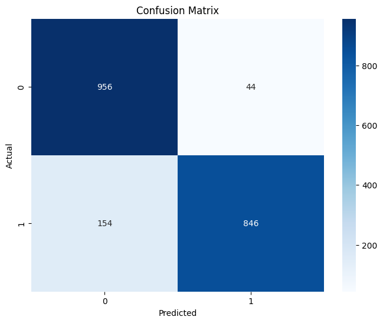

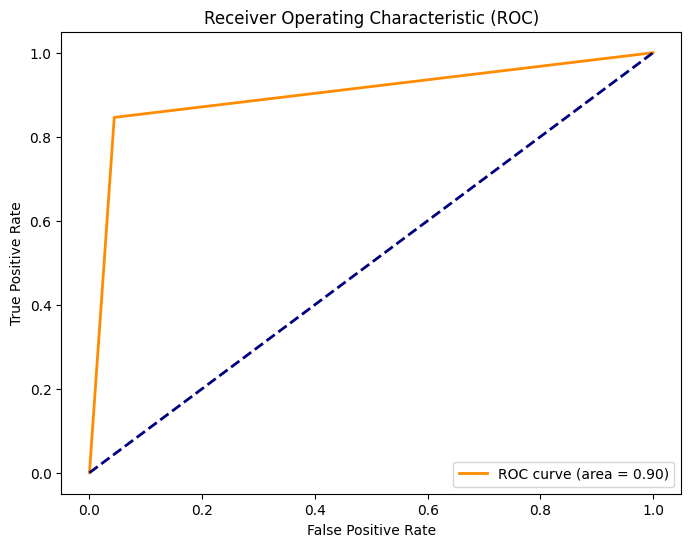

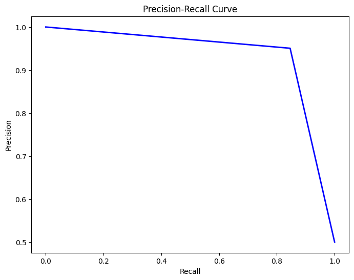

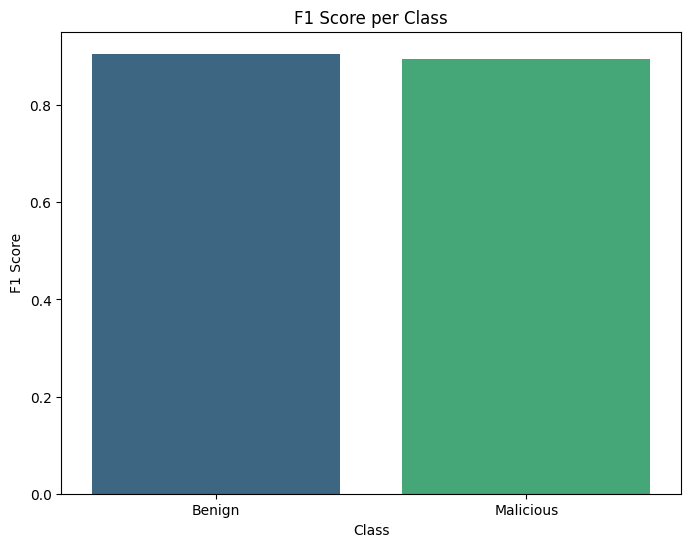

```
Overall Accuracy: 0.90
ROC AUC: 0.90
              precision    recall  f1-score   support

           0       0.86      0.96      0.91      1000
           1       0.95      0.85      0.90      1000

    accuracy                           0.90      2000
   macro avg       0.91      0.90      0.90      2000
weighted avg       0.91      0.90      0.90      2000
```

```python
import os
import numpy as np
import pandas as pd
import matplotlib.pyplot as plt
import seaborn as sns
from transformers import AutoTokenizer, AutoModelForSequenceClassification, Trainer, TrainingArguments, EarlyStoppingCallback, get_scheduler
from datasets import Dataset
import torch
from sklearn.metrics import confusion_matrix, classification_report, roc_curve, auc, precision_recall_curve, f1_score
from torch.optim import AdamW

# Disable tokenizers parallelism warning
os.environ["TOKENIZERS_PARALLELISM"] = "false"

# Step 1: Load the training and testing datasets
train_data_path = 'NSLKDD-dataset/kdd_train.csv'
test_data_path = 'NSLKDD-dataset/kdd_test.csv'

# Read the CSV files into pandas dataframes
train_df = pd.read_csv(train_data_path)
test_df = pd.read_csv(test_data_path)

# Step 2: Select only the important features for training
selected_columns = [
    'duration', 'protocol_type', 'service', 'src_bytes', 'dst_bytes', 'count', 'serror_rate',
    'rerror_rate', 'diff_srv_rate', 'srv_count', 'srv_diff_host_rate', 'dst_host_count',
    'dst_host_srv_count', 'dst_host_same_srv_rate', 'dst_host_diff_srv_rate', 'labels'
]

# Make sure the selected columns are present in the dataset
selected_columns = [col for col in selected_columns if col in train_df.columns]

train_df = train_df[selected_columns]
test_df = test_df[selected_columns]

# Step 3: Preprocess Data
# Convert labels into binary labels (1 for malicious, 0 for benign)
train_df['labels'] = train_df['labels'].apply(lambda x: 1 if x != 'normal' else 0)
test_df['labels'] = test_df['labels'].apply(lambda x: 1 if x != 'normal' else 0)

# Normalize numerical columns for better model performance
from sklearn.preprocessing import StandardScaler
scaler = StandardScaler()

# Identify numeric columns and scale them
numeric_cols = train_df.select_dtypes(include=[np.number]).columns.tolist()
numeric_cols.remove('labels')

train_df[numeric_cols] = scaler.fit_transform(train_df[numeric_cols])
test_df[numeric_cols] = scaler.transform(test_df[numeric_cols])

# Updated Step 4: Stratified Sampling to Increase Sample Size
train_df = train_df.groupby('labels', group_keys=False).apply(lambda x: x.sample(n=5000, random_state=42))
test_df = test_df.groupby('labels', group_keys=False).apply(lambda x: x.sample(n=1000, random_state=42))

# Step 5: Data Augmentation to Mitigate Overfitting
def add_noise(df, columns, noise_level=0.01):
    noisy_df = df.copy()
    for col in columns:
        if df[col].dtype in [np.float64, np.int64]:
            noise = np.random.normal(0, noise_level, len(df))
            noisy_df[col] = df[col] + noise
    return noisy_df

train_df = add_noise(train_df, selected_columns[:-1], noise_level=0.02)

# Step 6: Convert Data into Text Format for LLM Analysis
def convert_to_text(df):
    new_dataset = []
    for _, row in df.iterrows():
        text = "### Instruction:\n"
        for col in df.columns[:-1]:  # Exclude the 'labels' column
            text += f"{col}: {row[col]}\n"
        text += f"### Output:\n{row['labels']}"
        new_dataset.append(text)
    return new_dataset

train_text = convert_to_text(train_df)
test_text = convert_to_text(test_df)

# Step 7: Tokenize the Textual Data
model_name = "distilroberta-base"
tokenizer = AutoTokenizer.from_pretrained(model_name)

train_encodings = tokenizer(train_text, truncation=True, padding=True, max_length=128)
test_encodings = tokenizer(test_text, truncation=True, padding=True, max_length=128)

# Create Dataset Object for Hugging Face
def create_dataset(encodings, labels):
    return Dataset.from_dict({
        'input_ids': encodings['input_ids'],
        'attention_mask': encodings['attention_mask'],
        'labels': labels
    })

train_labels = train_df['labels'].tolist()
test_labels = test_df['labels'].tolist()

train_dataset = create_dataset(train_encodings, train_labels)
test_dataset = create_dataset(test_encodings, test_labels)

# Step 8: Load the Pre-trained Model
model = AutoModelForSequenceClassification.from_pretrained(model_name, num_labels=2)

# Move model to GPU if available
device = torch.device("cuda") if torch.cuda.is_available() else torch.device("cpu")
model = model.to(device)

# Step 9: Define Training Arguments with Improvements
training_args = TrainingArguments(
    output_dir='./results',
    evaluation_strategy="epoch",
    save_strategy="epoch",
    per_device_train_batch_size=16,  # Increased batch size for better GPU utilization
    gradient_accumulation_steps=4,  # Accumulate gradients for better stability
    num_train_epochs=5,
    weight_decay=0.3,  # L2 regularization to reduce overfitting
    learning_rate=5e-6,  # Reduced learning rate for smoother convergence
    logging_strategy="steps",
    logging_steps=50,
    load_best_model_at_end=True,
    fp16=torch.cuda.is_available(),  # Enable mixed precision training if GPU is available
    report_to="none",  # Disable reporting to external tools
    dataloader_num_workers=20,  # Utilize 20 CPUs for data loading
    max_grad_norm=1.0,  # Gradient clipping
)

# Step 10: Define Optimizer and Scheduler
optimizer = AdamW(model.parameters(), lr=5e-6, weight_decay=0.3)
total_steps = len(train_dataset) * training_args.num_train_epochs // (training_args.gradient_accumulation_steps * training_args.per_device_train_batch_size)
scheduler = get_scheduler("linear", optimizer=optimizer, num_warmup_steps=0, num_training_steps=total_steps)

# Step 11: Define the Trainer with Early Stopping and Data Collation
trainer = Trainer(
    model=model,
    args=training_args,
    train_dataset=train_dataset,
    eval_dataset=test_dataset,
    optimizers=(optimizer, scheduler),
    callbacks=[EarlyStoppingCallback(early_stopping_patience=5)]
)

# Step 12: Train the Model
trainer.train()

# Step 13: Evaluate the Model
predictions, labels, _ = trainer.predict(test_dataset)
predictions = np.argmax(predictions, axis=1)

# Step 14: Visualize Model Performance
# Confusion Matrix
conf_matrix = confusion_matrix(labels, predictions)
plt.figure(figsize=(8, 6))
sns.heatmap(conf_matrix, annot=True, fmt="d", cmap="Blues")
plt.title("Confusion Matrix")
plt.xlabel("Predicted")
plt.ylabel("Actual")
plt.show()

# ROC Curve
fpr, tpr, _ = roc_curve(labels, predictions)
roc_auc = auc(fpr, tpr)
plt.figure(figsize=(8, 6))
plt.plot(fpr, tpr, color='darkorange', lw=2, label=f'ROC curve (area = {roc_auc:.2f})')
plt.plot([0, 1], [0, 1], color='navy', lw=2, linestyle='--')
plt.xlabel('False Positive Rate')
plt.ylabel('True Positive Rate')
plt.title('Receiver Operating Characteristic (ROC)')
plt.legend(loc="lower right")
plt.show()

# Precision-Recall Curve
precision, recall, _ = precision_recall_curve(labels, predictions)
plt.figure(figsize=(8, 6))
plt.plot(recall, precision, color='b', lw=2)
plt.xlabel('Recall')
plt.ylabel('Precision')
plt.title('Precision-Recall Curve')
plt.show()

# F1 Score per Class
f1_scores = f1_score(labels, predictions, average=None)
plt.figure(figsize=(8, 6))
sns.barplot(x=['Benign', 'Malicious'], y=f1_scores, palette='viridis')
plt.title('F1 Score per Class')
plt.ylabel('F1 Score')
plt.xlabel('Class')
plt.show()

# Step 15: Draw Conclusions
accuracy = (conf_matrix[0, 0] + conf_matrix[1, 1]) / np.sum(conf_matrix)
print(f'Overall Accuracy: {accuracy:.2f}')
print(f'ROC AUC: {roc_auc:.2f}')
print(classification_report(labels, predictions))
```

### training dataset to use 20,000 samples and test dataset to use 5,000

[1250/1560 3:47:47 < 56:34, 0.09 it/s, Epoch 8/10]

| Epoch | Training Loss | Validation Loss |
| --- | --- | --- |
| 0 | 0.150400 | 0.296239 |
| 1 | 0.125700 | 0.298866 |
| 2 | 0.123100 | 0.286770 |
| 4 | 0.116500 | 0.327492 |
| 5 | 0.110200 | 0.340314 |
| 6 | 0.104200 | 0.316666 |
| 8 | 0.114600 | 0.331615 |

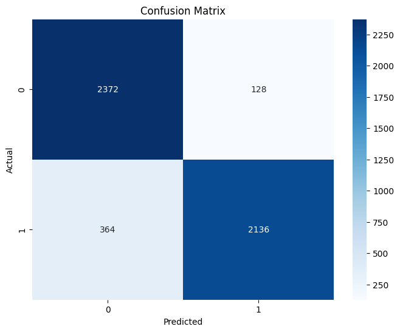

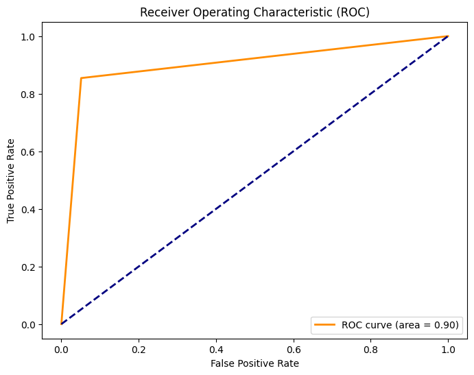

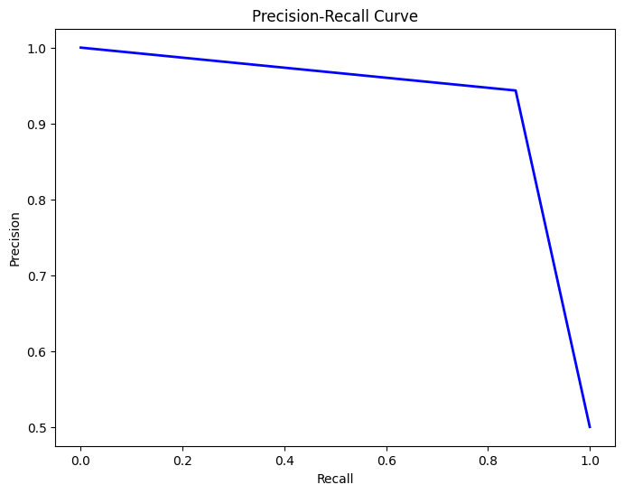

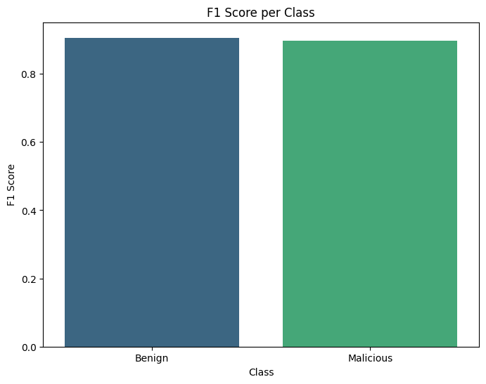

```
Overall Accuracy: 0.90
ROC AUC: 0.90
              precision    recall  f1-score   support

           0       0.87      0.95      0.91      2500
           1       0.94      0.85      0.90      2500

    accuracy                           0.90      5000
   macro avg       0.91      0.90      0.90      5000
weighted avg       0.91      0.90      0.90      5000
```

```python
import os
import numpy as np
import pandas as pd
import matplotlib.pyplot as plt
import seaborn as sns
from transformers import AutoTokenizer, AutoModelForSequenceClassification, Trainer, TrainingArguments, EarlyStoppingCallback, get_scheduler
from datasets import Dataset
import torch
from sklearn.metrics import confusion_matrix, classification_report, roc_curve, auc, precision_recall_curve, f1_score
from torch.optim import AdamW

# Disable tokenizers parallelism warning
os.environ["TOKENIZERS_PARALLELISM"] = "false"

# Step 1: Load the training and testing datasets
train_data_path = 'NSLKDD-dataset/kdd_train.csv'
test_data_path = 'NSLKDD-dataset/kdd_test.csv'

# Read the CSV files into pandas dataframes
train_df = pd.read_csv(train_data_path)
test_df = pd.read_csv(test_data_path)

# Step 2: Select only the important features for training
selected_columns = [
    'duration', 'protocol_type', 'service', 'src_bytes', 'dst_bytes', 'count', 'serror_rate',
    'rerror_rate', 'diff_srv_rate', 'srv_count', 'srv_diff_host_rate', 'dst_host_count',
    'dst_host_srv_count', 'dst_host_same_srv_rate', 'dst_host_diff_srv_rate', 'labels'
]

# Make sure the selected columns are present in the dataset
selected_columns = [col for col in selected_columns if col in train_df.columns]

train_df = train_df[selected_columns]
test_df = test_df[selected_columns]

# Step 3: Preprocess Data
# Convert labels into binary labels (1 for malicious, 0 for benign)
train_df['labels'] = train_df['labels'].apply(lambda x: 1 if x != 'normal' else 0)
test_df['labels'] = test_df['labels'].apply(lambda x: 1 if x != 'normal' else 0)

# Normalize numerical columns for better model performance
from sklearn.preprocessing import StandardScaler
scaler = StandardScaler()

# Identify numeric columns and scale them
numeric_cols = train_df.select_dtypes(include=[np.number]).columns.tolist()
numeric_cols.remove('labels')

train_df[numeric_cols] = scaler.fit_transform(train_df[numeric_cols])
test_df[numeric_cols] = scaler.transform(test_df[numeric_cols])

# Step 4: Stratified Sampling to Increase Sample Size
# Increased the sample size to 20,000 for training and 5,000 for validation
train_df = train_df.groupby('labels', group_keys=False).apply(lambda x: x.sample(n=10000, random_state=42))
test_df = test_df.groupby('labels', group_keys=False).apply(lambda x: x.sample(n=2500, random_state=42))

# Step 5: Data Augmentation to Mitigate Overfitting
def add_noise(df, columns, noise_level=0.01):
    noisy_df = df.copy()
    for col in columns:
        if df[col].dtype in [np.float64, np.int64]:
            noise = np.random.normal(0, noise_level, len(df))
            noisy_df[col] = df[col] + noise
    return noisy_df

train_df = add_noise(train_df, selected_columns[:-1], noise_level=0.02)

# Step 6: Convert Data into Text Format for LLM Analysis
def convert_to_text(df):
    new_dataset = []
    for _, row in df.iterrows():
        text = "### Instruction:\n"
        for col in df.columns[:-1]:  # Exclude the 'labels' column
            text += f"{col}: {row[col]}\n"
        text += f"### Output:\n{row['labels']}"
        new_dataset.append(text)
    return new_dataset

train_text = convert_to_text(train_df)
test_text = convert_to_text(test_df)

# Step 7: Tokenize the Textual Data
model_name = "distilroberta-base"
tokenizer = AutoTokenizer.from_pretrained(model_name)

train_encodings = tokenizer(train_text, truncation=True, padding=True, max_length=128)
test_encodings = tokenizer(test_text, truncation=True, padding=True, max_length=128)

# Create Dataset Object for Hugging Face
def create_dataset(encodings, labels):
    return Dataset.from_dict({
        'input_ids': encodings['input_ids'],
        'attention_mask': encodings['attention_mask'],
        'labels': labels
    })

train_labels = train_df['labels'].tolist()
test_labels = test_df['labels'].tolist()

train_dataset = create_dataset(train_encodings, train_labels)
test_dataset = create_dataset(test_encodings, test_labels)

# Step 8: Load the Pre-trained Model
model = AutoModelForSequenceClassification.from_pretrained(model_name, num_labels=2)

# Move model to GPU if available
device = torch.device("cuda") if torch.cuda.is_available() else torch.device("cpu")
model = model.to(device)

# Step 9: Define Training Arguments with Improvements
training_args = TrainingArguments(
    output_dir='./results',
    evaluation_strategy="epoch",
    save_strategy="epoch",
    per_device_train_batch_size=32,  # Increased batch size for better GPU utilization
    gradient_accumulation_steps=4,  # Accumulate gradients for better stability
    num_train_epochs=10,
    weight_decay=0.3,  # L2 regularization to reduce overfitting
    learning_rate=5e-6,  # Reduced learning rate for smoother convergence
    logging_strategy="steps",
    logging_steps=50,
    load_best_model_at_end=True,
    fp16=torch.cuda.is_available(),  # Enable mixed precision training if GPU is available
    report_to="none",  # Disable reporting to external tools
    dataloader_num_workers=20,  # Utilize 20 CPUs for data loading
    max_grad_norm=1.0,  # Gradient clipping
)

# Step 10: Define Optimizer and Scheduler
optimizer = AdamW(model.parameters(), lr=5e-6, weight_decay=0.3)
total_steps = len(train_dataset) * training_args.num_train_epochs // (training_args.gradient_accumulation_steps * training_args.per_device_train_batch_size)
scheduler = get_scheduler("linear", optimizer=optimizer, num_warmup_steps=0, num_training_steps=total_steps)

# Step 11: Define the Trainer with Early Stopping and Data Collation
trainer = Trainer(
    model=model,
    args=training_args,
    train_dataset=train_dataset,
    eval_dataset=test_dataset,
    optimizers=(optimizer, scheduler),
    callbacks=[EarlyStoppingCallback(early_stopping_patience=5)]
)

# Step 12: Train the Model
trainer.train()

# Step 13: Evaluate the Model
predictions, labels, _ = trainer.predict(test_dataset)
predictions = np.argmax(predictions, axis=1)

# Step 14: Visualize Model Performance
# Confusion Matrix
conf_matrix = confusion_matrix(labels, predictions)
plt.figure(figsize=(8, 6))
sns.heatmap(conf_matrix, annot=True, fmt="d", cmap="Blues")
plt.title("Confusion Matrix")
plt.xlabel("Predicted")
plt.ylabel("Actual")
plt.show()

# ROC Curve
fpr, tpr, _ = roc_curve(labels, predictions)
roc_auc = auc(fpr, tpr)
plt.figure(figsize=(8, 6))
plt.plot(fpr, tpr, color='darkorange', lw=2, label=f'ROC curve (area = {roc_auc:.2f})')
plt.plot([0, 1], [0, 1], color='navy', lw=2, linestyle='--')
plt.xlabel('False Positive Rate')
plt.ylabel('True Positive Rate')
plt.title('Receiver Operating Characteristic (ROC)')
plt.legend(loc="lower right")
plt.show()

# Precision-Recall Curve
precision, recall, _ = precision_recall_curve(labels, predictions)
plt.figure(figsize=(8, 6))
plt.plot(recall, precision, color='b', lw=2)
plt.xlabel('Recall')
plt.ylabel('Precision')
plt.title('Precision-Recall Curve')
plt.show()

# F1 Score per Class
f1_scores = f1_score(labels, predictions, average=None)
plt.figure(figsize=(8, 6))
sns.barplot(x=['Benign', 'Malicious'], y=f1_scores, palette='viridis')
plt.title('F1 Score per Class')
plt.ylabel('F1 Score')
plt.xlabel('Class')
plt.show()

# Step 15: Draw Conclusions
accuracy = (conf_matrix[0, 0] + conf_matrix[1, 1]) / np.sum(conf_matrix)
print(f'Overall Accuracy: {accuracy:.2f}')
print(f'ROC AUC: {roc_auc:.2f}')
print(classification_report(labels, predictions))
```

```
Some weights of RobertaForSequenceClassification were not initialized from the model checkpoint at distilroberta-base and are newly initialized: ['classifier.dense.bias', 'classifier.dense.weight', 'classifier.out_proj.bias', 'classifier.out_proj.weight']
You should probably TRAIN this model on a down-stream task to be able to use it for predictions and inference.
```

[4920/4920 14:49:33, Epoch 4/5]

| Epoch | Training Loss | Validation Loss |
| --- | --- | --- |
| 0 | 0.120200 | 0.314580 |
| 1 | 0.114000 | 0.322570 |
| 2 | 0.108300 | 0.308991 |
| 4 | 0.107900 | 0.320225 |

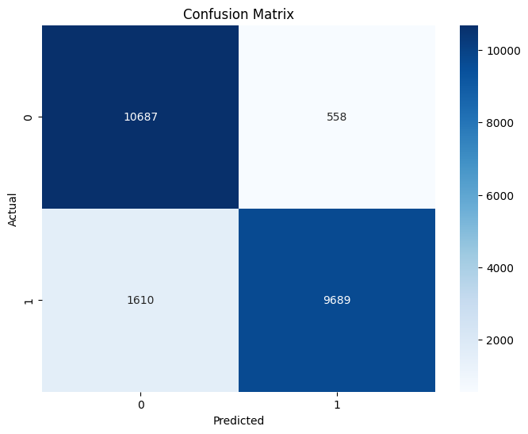

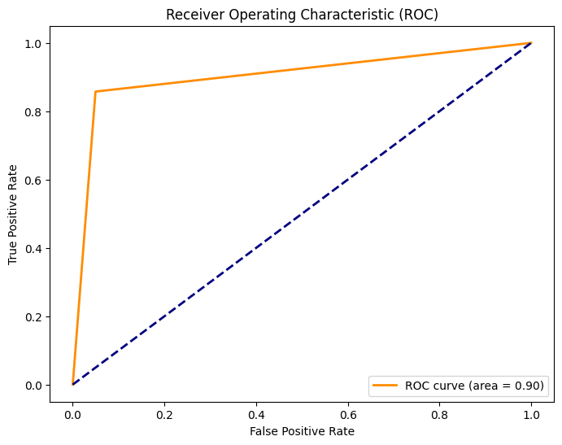

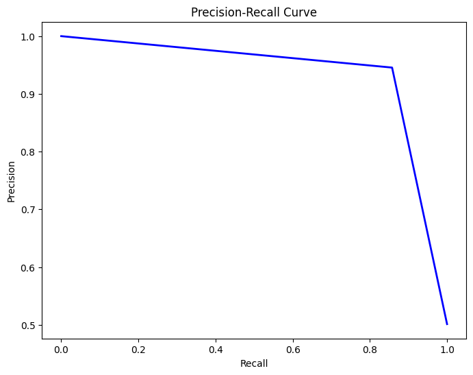

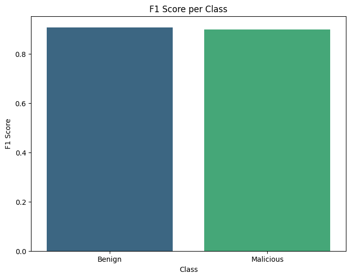

```
Overall Accuracy: 0.90
ROC AUC: 0.90
              precision    recall  f1-score   support

           0       0.87      0.95      0.91     11245
           1       0.95      0.86      0.90     11299

    accuracy                           0.90     22544
   macro avg       0.91      0.90      0.90     22544
weighted avg       0.91      0.90      0.90     22544


Setting up SHAP for Explainability...
```

[output not shown]

```python
import os
import numpy as np
import pandas as pd
import matplotlib.pyplot as plt
import seaborn as sns
from transformers import AutoTokenizer, AutoModelForSequenceClassification, Trainer, TrainingArguments, EarlyStoppingCallback, get_scheduler
from datasets import Dataset
import torch
from sklearn.metrics import confusion_matrix, classification_report, roc_curve, auc, precision_recall_curve, f1_score
from torch.optim import AdamW
import shap

# Disable tokenizers parallelism warning
os.environ["TOKENIZERS_PARALLELISM"] = "false"

# Step 1: Load the training and testing datasets
train_data_path = 'NSLKDD-dataset/kdd_train.csv'
test_data_path = 'NSLKDD-dataset/kdd_test.csv'

# Read the CSV files into pandas dataframes
train_df = pd.read_csv(train_data_path)
test_df = pd.read_csv(test_data_path)

# Step 2: Select only the important features for training
selected_columns = [
    'duration', 'protocol_type', 'service', 'src_bytes', 'dst_bytes', 'count', 'serror_rate',
    'rerror_rate', 'diff_srv_rate', 'srv_count', 'srv_diff_host_rate', 'dst_host_count',
    'dst_host_srv_count', 'dst_host_same_srv_rate', 'dst_host_diff_srv_rate', 'labels'
]

# Make sure the selected columns are present in the dataset
selected_columns = [col for col in selected_columns if col in train_df.columns]

train_df = train_df[selected_columns]
test_df = test_df[selected_columns]

# Step 3: Preprocess Data
# Convert labels into binary labels (1 for malicious, 0 for benign)
train_df['labels'] = train_df['labels'].apply(lambda x: 1 if x != 'normal' else 0)
test_df['labels'] = test_df['labels'].apply(lambda x: 1 if x != 'normal' else 0)

# Normalize numerical columns for better model performance
from sklearn.preprocessing import StandardScaler
scaler = StandardScaler()

# Identify numeric columns and scale them
numeric_cols = train_df.select_dtypes(include=[np.number]).columns.tolist()
numeric_cols.remove('labels')

train_df[numeric_cols] = scaler.fit_transform(train_df[numeric_cols])
test_df[numeric_cols] = scaler.transform(test_df[numeric_cols])

# Step 4: Remove Sampling - Use Full Dataset
# Using full training and testing datasets

# Step 5: Data Augmentation to Mitigate Overfitting
def add_noise(df, columns, noise_level=0.01):
    noisy_df = df.copy()
    for col in columns:
        if df[col].dtype in [np.float64, np.int64]:
            noise = np.random.normal(0, noise_level, len(df))
            noisy_df[col] = df[col] + noise
    return noisy_df

train_df = add_noise(train_df, selected_columns[:-1], noise_level=0.02)

# Step 6: Convert Data into Text Format for LLM Analysis
def convert_to_text(df):
    new_dataset = []
    for _, row in df.iterrows():
        text = "### Instruction:\n"
        for col in df.columns[:-1]:  # Exclude the 'labels' column
            text += f"{col}: {row[col]}\n"
        text += f"### Output:\n{row['labels']}"
        new_dataset.append(text)
    return new_dataset

train_text = convert_to_text(train_df)
test_text = convert_to_text(test_df)

# Step 7: Tokenize the Textual Data
model_name = "distilroberta-base"
tokenizer = AutoTokenizer.from_pretrained(model_name)

train_encodings = tokenizer(train_text, truncation=True, padding=True, max_length=128)
test_encodings = tokenizer(test_text, truncation=True, padding=True, max_length=128)

# Create Dataset Object for Hugging Face
def create_dataset(encodings, labels):
    return Dataset.from_dict({
        'input_ids': encodings['input_ids'],
        'attention_mask': encodings['attention_mask'],
        'labels': labels
    })

train_labels = train_df['labels'].tolist()
test_labels = test_df['labels'].tolist()

train_dataset = create_dataset(train_encodings, train_labels)
test_dataset = create_dataset(test_encodings, test_labels)

# Step 8: Load the Pre-trained Model with Dropout for Regularization
model = AutoModelForSequenceClassification.from_pretrained(model_name, num_labels=2)
model.config.hidden_dropout_prob = 0.3  # Adding dropout to reduce overfitting

# Move model to GPU if available
device = torch.device("cuda") if torch.cuda.is_available() else torch.device("cpu")
model = model.to(device)

# Step 9: Define Training Arguments with Improvements
training_args = TrainingArguments(
    output_dir='./results',
    evaluation_strategy="epoch",
    save_strategy="epoch",
    per_device_train_batch_size=32,  # Increased batch size for better GPU utilization
    gradient_accumulation_steps=4,  # Accumulate gradients for better stability
    num_train_epochs=5,  # Reduced epochs to prevent overfitting
    weight_decay=0.3,  # L2 regularization to reduce overfitting
    learning_rate=3e-6,  # Reduced learning rate for smoother convergence
    logging_strategy="steps",
    logging_steps=50,
    load_best_model_at_end=True,
    fp16=torch.cuda.is_available(),  # Enable mixed precision training if GPU is available
    report_to="none",  # Disable reporting to external tools
    dataloader_num_workers=20,  # Utilize 20 CPUs for data loading
    max_grad_norm=1.0,  # Gradient clipping
)

# Step 10: Define Optimizer and Scheduler
optimizer = AdamW(model.parameters(), lr=3e-6, weight_decay=0.3)
total_steps = len(train_dataset) * training_args.num_train_epochs // (training_args.gradient_accumulation_steps * training_args.per_device_train_batch_size)
scheduler = get_scheduler("linear", optimizer=optimizer, num_warmup_steps=0, num_training_steps=total_steps)

# Step 11: Define the Trainer with Early Stopping and Data Collation
trainer = Trainer(
    model=model,
    args=training_args,
    train_dataset=train_dataset,
    eval_dataset=test_dataset,
    optimizers=(optimizer, scheduler),
    callbacks=[EarlyStoppingCallback(early_stopping_patience=3)]
)

# Step 12: Train the Model
trainer.train()

# Step 13: Evaluate the Model
predictions, labels, _ = trainer.predict(test_dataset)
predictions = np.argmax(predictions, axis=1)

# Step 14: Visualize Model Performance
# Confusion Matrix
conf_matrix = confusion_matrix(labels, predictions)
plt.figure(figsize=(8, 6))
sns.heatmap(conf_matrix, annot=True, fmt="d", cmap="Blues")
plt.title("Confusion Matrix")
plt.xlabel("Predicted")
plt.ylabel("Actual")
plt.show()

# ROC Curve
fpr, tpr, _ = roc_curve(labels, predictions)
roc_auc = auc(fpr, tpr)
plt.figure(figsize=(8, 6))
plt.plot(fpr, tpr, color='darkorange', lw=2, label=f'ROC curve (area = {roc_auc:.2f})')
plt.plot([0, 1], [0, 1], color='navy', lw=2, linestyle='--')
plt.xlabel('False Positive Rate')
plt.ylabel('True Positive Rate')
plt.title('Receiver Operating Characteristic (ROC)')
plt.legend(loc="lower right")
plt.show()

# Precision-Recall Curve
precision, recall, _ = precision_recall_curve(labels, predictions)
plt.figure(figsize=(8, 6))
plt.plot(recall, precision, color='b', lw=2)
plt.xlabel('Recall')
plt.ylabel('Precision')
plt.title('Precision-Recall Curve')
plt.show()

# F1 Score per Class
f1_scores = f1_score(labels, predictions, average=None)
plt.figure(figsize=(8, 6))
sns.barplot(x=['Benign', 'Malicious'], y=f1_scores, palette='viridis')
plt.title('F1 Score per Class')
plt.ylabel('F1 Score')
plt.xlabel('Class')
plt.show()

# Step 15: Draw Conclusions
accuracy = (conf_matrix[0, 0] + conf_matrix[1, 1]) / np.sum(conf_matrix)
print(f'Overall Accuracy: {accuracy:.2f}')
print(f'ROC AUC: {roc_auc:.2f}')
print(classification_report(labels, predictions))

# Step 16: Explainability with SHAP
# print("\nSetting up SHAP for Explainability...")
# # Convert dataset to format suitable for SHAP
# explainer = shap.Explainer(model, train_dataset)
# shap_values = explainer(train_dataset[:100])  # Limiting to 100 samples for efficiency

# # Plot feature importance
# shap.summary_plot(shap_values, train_dataset[:100], feature_names=selected_columns[:-1])
```

```python
import shap
from transformers import AutoTokenizer
import numpy as np

# Step 16: Explainability with SHAP
print("\nSetting up SHAP for Explainability...")

# Convert a subset of the train data to text to be used for SHAP explainability
sample_data = train_df.sample(n=20, random_state=42)
sample_texts = convert_to_text(sample_data)

# Tokenize the textual data
tokenizer = AutoTokenizer.from_pretrained(model_name)
sample_encodings = tokenizer(sample_texts, truncation=True, padding=True, max_length=128, return_tensors='pt')

# Move inputs to device
input_ids = sample_encodings['input_ids'].to(device)
attention_mask = sample_encodings['attention_mask'].to(device)

# Create a wrapper function for the model to return logits for explainability
def model_predict(inputs):
    input_ids = torch.tensor(inputs, dtype=torch.long).to(device)
    attention_mask = torch.ones_like(input_ids).to(device)

    # Make predictions using the model
    with torch.no_grad():
        outputs = model(input_ids=input_ids, attention_mask=attention_mask)
        return outputs.logits.cpu().numpy()

# Convert input_ids to numpy array for SHAP
input_ids_np = input_ids.cpu().numpy()

# Use KernelExplainer with a subset of the training data
explainer = shap.KernelExplainer(model_predict, input_ids_np)

# Explain predictions on the subset of the dataset (using the same 100 samples)
shap_values = explainer.shap_values(input_ids_np)

# Plot feature importance
shap.summary_plot(shap_values, input_ids_np, feature_names=tokenizer.convert_ids_to_tokens(input_ids[0]))
```

```
Setting up SHAP for Explainability...
```

[output not shown]

[155/155 14:55, Epoch 4/5]

| Epoch | Training Loss | Validation Loss |
| --- | --- | --- |
| 0 | No log | 0.691352 |
| 1 | 0.694200 | 0.681317 |
| 2 | 0.694200 | 0.579532 |
| 4 | 0.413000 | 0.317907 |

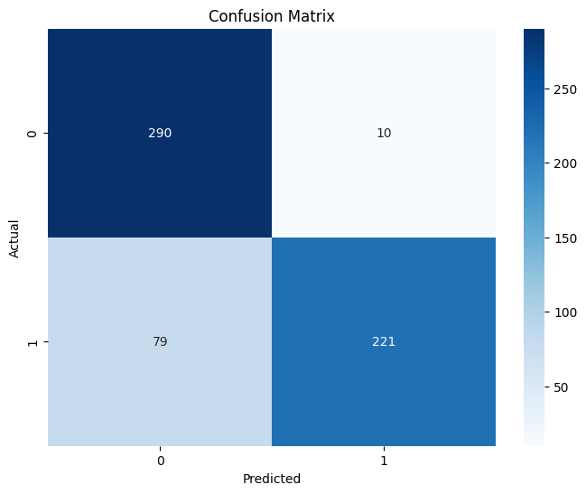

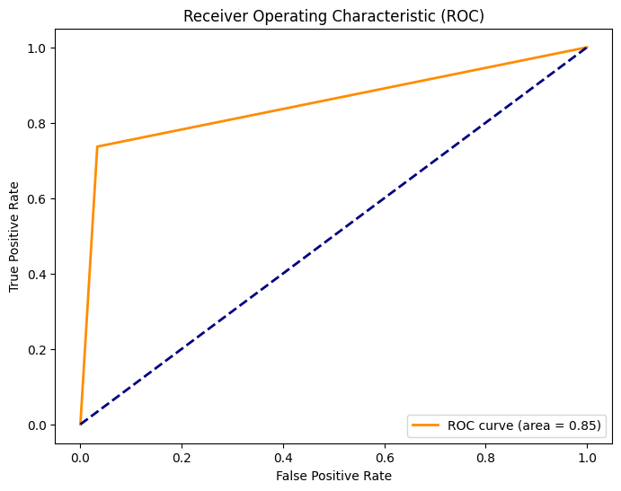

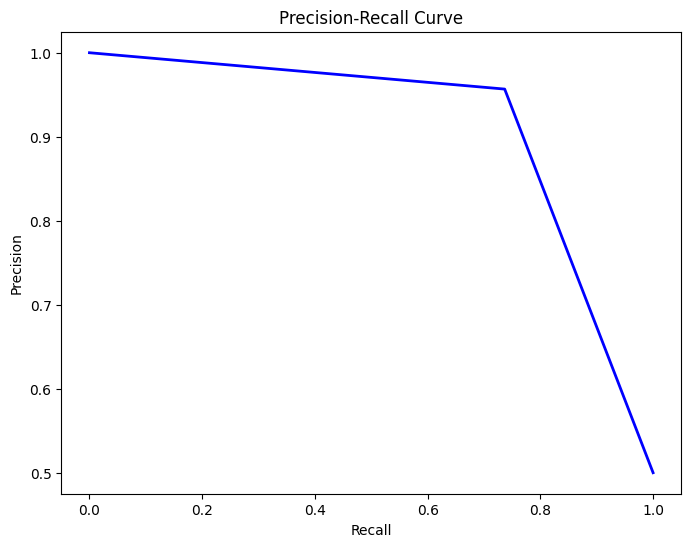

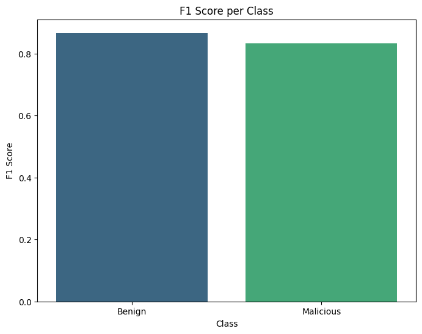

```
Overall Accuracy: 0.85
ROC AUC: 0.85
              precision    recall  f1-score   support

           0       0.79      0.97      0.87       300
           1       0.96      0.74      0.83       300

    accuracy                           0.85       600
   macro avg       0.87      0.85      0.85       600
weighted avg       0.87      0.85      0.85       600
```

```
('./saved_model/tokenizer_config.json',
 './saved_model/special_tokens_map.json',
 './saved_model/vocab.json',
 './saved_model/merges.txt',
 './saved_model/added_tokens.json',
 './saved_model/tokenizer.json')
```

```python
import os
import numpy as np
import pandas as pd
import matplotlib.pyplot as plt
import seaborn as sns
from transformers import AutoTokenizer, AutoModelForSequenceClassification, Trainer, TrainingArguments, EarlyStoppingCallback, get_scheduler
from datasets import Dataset
import torch
from sklearn.metrics import confusion_matrix, classification_report, roc_curve, auc, precision_recall_curve, f1_score
from torch.optim import AdamW

# Disable tokenizers parallelism warning
os.environ["TOKENIZERS_PARALLELISM"] = "false"

# Step 1: Load the training and testing datasets
train_data_path = 'NSLKDD-dataset/kdd_train.csv'
test_data_path = 'NSLKDD-dataset/kdd_test.csv'

# Read the CSV files into pandas dataframes
train_df = pd.read_csv(train_data_path)
test_df = pd.read_csv(test_data_path)

# Step 2: Select only the important features for training
selected_columns = [
    'duration', 'protocol_type', 'service', 'src_bytes', 'dst_bytes', 'count', 'serror_rate',
    'rerror_rate', 'diff_srv_rate', 'srv_count', 'srv_diff_host_rate', 'dst_host_count',
    'dst_host_srv_count', 'dst_host_same_srv_rate', 'dst_host_diff_srv_rate', 'labels'
]

# Make sure the selected columns are present in the dataset
selected_columns = [col for col in selected_columns if col in train_df.columns]

train_df = train_df[selected_columns]
test_df = test_df[selected_columns]

# Step 3: Preprocess Data
# Convert labels into binary labels (1 for malicious, 0 for benign)
train_df['labels'] = train_df['labels'].apply(lambda x: 1 if x != 'normal' else 0)
test_df['labels'] = test_df['labels'].apply(lambda x: 1 if x != 'normal' else 0)

# Normalize numerical columns for better model performance
from sklearn.preprocessing import StandardScaler
scaler = StandardScaler()

# Identify numeric columns and scale them
numeric_cols = train_df.select_dtypes(include=[np.number]).columns.tolist()
numeric_cols.remove('labels')

train_df[numeric_cols] = scaler.fit_transform(train_df[numeric_cols])
test_df[numeric_cols] = scaler.transform(test_df[numeric_cols])

# Updated Step 4: Stratified Sampling to Increase Sample Size
train_df = train_df.groupby('labels', group_keys=False).apply(lambda x: x.sample(n=1000, random_state=42))
test_df = test_df.groupby('labels', group_keys=False).apply(lambda x: x.sample(n=300, random_state=42))

# Step 5: Data Augmentation to Mitigate Overfitting
def add_noise(df, columns, noise_level=0.01):
    noisy_df = df.copy()
    for col in columns:
        if df[col].dtype in [np.float64, np.int64]:
            noise = np.random.normal(0, noise_level, len(df))
            noisy_df[col] = df[col] + noise
    return noisy_df

train_df = add_noise(train_df, selected_columns[:-1], noise_level=0.02)

# Step 6: Convert Data into Text Format for LLM Analysis
def convert_to_text(df):
    new_dataset = []
    for _, row in df.iterrows():
        text = "### Instruction:\n"
        for col in df.columns[:-1]:  # Exclude the 'labels' column
            text += f"{col}: {row[col]}\n"
        text += f"### Output:\n{row['labels']}"
        new_dataset.append(text)
    return new_dataset

train_text = convert_to_text(train_df)
test_text = convert_to_text(test_df)

# Step 7: Tokenize the Textual Data
model_name = "distilroberta-base"
tokenizer = AutoTokenizer.from_pretrained(model_name)

train_encodings = tokenizer(train_text, truncation=True, padding=True, max_length=128)
test_encodings = tokenizer(test_text, truncation=True, padding=True, max_length=128)

# Create Dataset Object for Hugging Face
def create_dataset(encodings, labels):
    return Dataset.from_dict({
        'input_ids': encodings['input_ids'],
        'attention_mask': encodings['attention_mask'],
        'labels': labels
    })

train_labels = train_df['labels'].tolist()
test_labels = test_df['labels'].tolist()

train_dataset = create_dataset(train_encodings, train_labels)
test_dataset = create_dataset(test_encodings, test_labels)

# Step 8: Load the Pre-trained Model
model = AutoModelForSequenceClassification.from_pretrained(model_name, num_labels=2)

# Move model to GPU if available
device = torch.device("cuda") if torch.cuda.is_available() else torch.device("cpu")
model = model.to(device)

# Step 9: Define Training Arguments with Improvements
training_args = TrainingArguments(
    output_dir='./results',
    evaluation_strategy="epoch",
    save_strategy="epoch",
    per_device_train_batch_size=16,  # Increased batch size for better GPU utilization
    gradient_accumulation_steps=4,  # Accumulate gradients for better stability
    num_train_epochs=5,
    weight_decay=0.3,  # L2 regularization to reduce overfitting
    learning_rate=5e-6,  # Reduced learning rate for smoother convergence
    logging_strategy="steps",
    logging_steps=50,
    load_best_model_at_end=True,
    fp16=torch.cuda.is_available(),  # Enable mixed precision training if GPU is available
    report_to="none",  # Disable reporting to external tools
    dataloader_num_workers=20,  # Utilize 20 CPUs for data loading
    max_grad_norm=1.0,  # Gradient clipping
)

# Step 10: Define Optimizer and Scheduler
optimizer = AdamW(model.parameters(), lr=5e-6, weight_decay=0.3)
total_steps = len(train_dataset) * training_args.num_train_epochs // (training_args.gradient_accumulation_steps * training_args.per_device_train_batch_size)
scheduler = get_scheduler("linear", optimizer=optimizer, num_warmup_steps=0, num_training_steps=total_steps)

# Step 11: Define the Trainer with Early Stopping and Data Collation
trainer = Trainer(
    model=model,
    args=training_args,
    train_dataset=train_dataset,
    eval_dataset=test_dataset,
    optimizers=(optimizer, scheduler),
    callbacks=[EarlyStoppingCallback(early_stopping_patience=5)]
)

# Step 12: Train the Model
trainer.train()

# Step 13: Evaluate the Model
predictions, labels, _ = trainer.predict(test_dataset)
predictions = np.argmax(predictions, axis=1)

# Step 14: Visualize Model Performance
# Confusion Matrix
conf_matrix = confusion_matrix(labels, predictions)
plt.figure(figsize=(8, 6))
sns.heatmap(conf_matrix, annot=True, fmt="d", cmap="Blues")
plt.title("Confusion Matrix")
plt.xlabel("Predicted")
plt.ylabel("Actual")
plt.show()

# ROC Curve
fpr, tpr, _ = roc_curve(labels, predictions)
roc_auc = auc(fpr, tpr)
plt.figure(figsize=(8, 6))
plt.plot(fpr, tpr, color='darkorange', lw=2, label=f'ROC curve (area = {roc_auc:.2f})')
plt.plot([0, 1], [0, 1], color='navy', lw=2, linestyle='--')
plt.xlabel('False Positive Rate')
plt.ylabel('True Positive Rate')
plt.title('Receiver Operating Characteristic (ROC)')
plt.legend(loc="lower right")
plt.show()

# Precision-Recall Curve
precision, recall, _ = precision_recall_curve(labels, predictions)
plt.figure(figsize=(8, 6))
plt.plot(recall, precision, color='b', lw=2)
plt.xlabel('Recall')
plt.ylabel('Precision')
plt.title('Precision-Recall Curve')
plt.show()

# F1 Score per Class
f1_scores = f1_score(labels, predictions, average=None)
plt.figure(figsize=(8, 6))
sns.barplot(x=['Benign', 'Malicious'], y=f1_scores, palette='viridis')
plt.title('F1 Score per Class')
plt.ylabel('F1 Score')
plt.xlabel('Class')
plt.show()

# Step 15: Draw Conclusions
accuracy = (conf_matrix[0, 0] + conf_matrix[1, 1]) / np.sum(conf_matrix)
print(f'Overall Accuracy: {accuracy:.2f}')
print(f'ROC AUC: {roc_auc:.2f}')
print(classification_report(labels, predictions))

model.save_pretrained('./saved_model')
tokenizer.save_pretrained('./saved_model')
```

## Before calling SHAP, print out:

```python
print("Test Dataset Example (Tokenized Input IDs):")
print(test_encodings["input_ids"][:5])  # First 5 samples
print("Test Dataset Example (Attention Mask):")
print(test_encodings["attention_mask"][:5])  # First 5 samples
print("Test Dataset Labels:")
print(test_labels[:5])  # First 5 labels
```

```
Test Dataset Example (Tokenized Input IDs):
[[0, 48134, 41241, 35, 50118, 41218, 35, 111, 288, 4, 11670, 25048, 2036, 2881, 1092, 3414, 37634, 50118, 36299, 23558, 1215, 12528, 35, 49067, 50118, 11131, 35, 2054, 50118, 45692, 1215, 46823, 35, 111, 288, 4, 612, 4718, 2481, 1092, 38770, 26629, 4563, 1360, 50118, 417, 620, 1215, 46823, 35, 111, …
Test Dataset Example (Attention Mask):
[[1, 1, 1, 1, 1, 1, 1, 1, 1, 1, 1, 1, 1, 1, 1, 1, 1, 1, 1, 1, 1, 1, 1, 1, 1, 1, 1, 1, 1, 1, 1, 1, 1, 1, 1, 1, 1, 1, 1, 1, 1, 1, 1, 1, 1, 1, 1, 1, 1, 1, 1, 1, 1, 1, 1, 1, 1, 1, 1, 1, 1, 1, 1, 1, 1, 1, 1, 1, 1, 1, 1, 1, 1, 1, 1, 1, 1, 1, 1, 1, 1, 1, 1, 1, 1, 1, 1, 1, 1, 1, 1, 1, 1, 1, 1, 1, 1, 1, 1, 1…
Test Dataset Labels:
[0, 0, 0, 0, 0]
```

[output not shown]

[output cut: 18 more lines]

[figure not shown]

```python
import numpy as np
import shap

# Select a subset of test data for SHAP explanation
sample_size = 20  # Reduce for efficiency
test_sample = np.array(test_encodings["input_ids"][:sample_size])  # Convert list to NumPy array

# Ensure the data is in the correct format before passing to SHAP
print("Sample Input for SHAP (Tokenized Input IDs):", test_sample[:3])

# KernelExplainer requires a structured NumPy array as background data
background = np.array(test_encodings["input_ids"][:5])  # Convert list to NumPy array

# Initialize SHAP Explainer
explainer = shap.KernelExplainer(model_predict, background)

# Compute SHAP values
shap_values = explainer.shap_values(test_sample)

# Visualize SHAP summary
shap.summary_plot(shap_values, test_sample)
```

```python
test_batch = {k: torch.tensor(v[:5]).to(device) for k, v in test_encodings.items()}
with torch.no_grad():
    output = model(**test_batch)

print("Raw Model Logits:", output.logits)
print("Predicted Probabilities:", torch.softmax(output.logits, dim=1))
```

```
Raw Model Logits: tensor([[ 1.0619, -1.2572],
        [ 1.0702, -1.2583],
        [ 1.0649, -1.2566],
        [ 0.5908, -0.4432],
        [ 1.0603, -1.2629]])
Predicted Probabilities: tensor([[0.9104, 0.0896],
        [0.9112, 0.0888],
        [0.9106, 0.0894],
        [0.7377, 0.2623],
        [0.9108, 0.0892]])
```

```python
# Select a subset of test data for SHAP explanation
sample_size = 20  # Reduce for efficiency
test_sample = test_encodings["input_ids"][:sample_size]  # Select input_ids

# Ensure the data is in the correct format before passing to SHAP
print("Sample Input for SHAP (Tokenized Input IDs):", test_sample[:3])

# KernelExplainer requires a baseline (mean input in this case)
background = test_encodings["input_ids"][:5]  # Use first 5 samples as background

# Initialize SHAP Explainer
explainer = shap.KernelExplainer(model_predict, background)

# Compute SHAP values
shap_values = explainer.shap_values(test_sample)

# Visualize SHAP summary
shap.summary_plot(shap_values, test_sample)
```

## Check Model Output Before SHAP

Before we pass data to SHAP, we should verify the output format:

```python
test_batch = {k: torch.tensor(v[:5]).to(device) for k, v in test_encodings.items()}  # Select 5 samples
with torch.no_grad():
    output = model(**test_batch)
print("Raw Model Output (Logits):", output.logits)
print("Predictions:", torch.argmax(output.logits, dim=1))
```

[output not shown]